# Oxford Happiness Questionnaire

coop711

2018-10-29

옥스포드 행복 설문지 실험결과를 분석한다. 이 실험에는 두 가지 목적이 있다. 첫째는 있는 그대로 옥스포드 행복 설문지로 측정하는 여러분의 행복 수준은 어느 정도인지, 둘째는 영문판으로 응답할 때와 국문판으로 응답할 때 어떤 차이가 있는지, 특히 응답에 소요되는 시간을 측정해 보았다. 여러분이 직접 손으로 계산한 값과 컴퓨터로 계산한 값의 차이도 살펴본다.

## Data

| 학번 | 손점수 | 컴퓨터점수 | 차이 | 행복 수준 | 소요 시간 | 질문지 유형 |
| --- | --- | --- | --- | --- | --- | --- |
| 20175101 | 3.03 | 4.03 | -1.004 | 꽤 행복하다 | 7분30초 | 영문 |
| 20162502 | NA | NA | NA | NA | NA | 국문 |
| 20182102 | 4.10 | 4.21 | -0.107 | 꽤 행복하다 | 5분30초 | 영문 |
| 20183802 | 3.17 | 4.62 | -1.451 | 꽤 행복하다 | 8분21초 | 국문 |
| 20174103 | 4.00 | 4.10 | -0.103 | 꽤 행복하다 | 2분52초 | 국문 |
| 20185103 | NA | NA | NA | NA | NA | 국문 |
| 20183605 | 4.37 | 4.21 | 0.163 | 꽤 행복하다 | 11분27초 | 영문 |
| 20185107 | 2.96 | 2.97 | -0.006 | 다소 행복하지 않다 | 4분0초 | 국문 |
| 20183606 | 4.00 | 4.72 | -0.724 | 꽤 행복하다 | 2분35초 | 국문 |
| 20172101 | NA | NA | NA | NA | NA | 영문 |
| 20135106 | 3.52 | 3.55 | -0.032 | 그저 그렇다 | 3분21초 | 국문 |
| 20157031 | 4.50 | 4.52 | -0.017 | 꽤 행복하다 | 10분15초 | 국문 |
| 20135204 | 4.24 | 4.17 | 0.068 | 꽤 행복하다 | 9분6초 | 영문 |
| 20124308 | NA | NA | NA | NA | NA | 영문 |
| 20135306 | 3.60 | 3.66 | -0.055 | 그저 그렇다 | 5분1초 | 국문 |
| 20173004 | 2.70 | 2.69 | 0.010 | 다소 행복하지 않다 | 5분5초 | 국문 |
| 20183610 | 4.50 | 4.38 | 0.121 | 꽤 행복하다 | 7분6초 | 영문 |
| 20145209 | 3.65 | 4.14 | -0.488 | 꽤 행복하다 | 6분5초 | 영문 |
| 20133707 | 4.41 | 4.41 | -0.004 | 꽤 행복하다 | 5분50초 | 국문 |
| 20152710 | 4.60 | 4.62 | -0.021 | 꽤 행복하다 | 7분8초 | 국문 |
| 20186213 | 3.60 | 3.79 | -0.193 | 그저 그렇다 | 5분4초 | 국문 |
| 20122822 | 3.41 | 3.59 | -0.176 | 그저 그렇다 | 9분8초 | 영문 |
| 20131606 | 4.28 | 4.07 | 0.211 | 꽤 행복하다 | 4분59초 | 영문 |
| 20183806 | 3.96 | 3.97 | -0.006 | 그저 그렇다 | 7분21초 | 국문 |
| 20154209 | 4.03 | 4.14 | -0.108 | 꽤 행복하다 | 4분39초 | 영문 |
| 20163307 | NA | NA | NA | NA | NA | 국문 |
| 20183808 | 4.70 | 3.72 | 0.976 | 그저 그렇다 | 7분43초 | 영문 |
| 20121307 | 4.30 | 3.48 | 0.817 | 그저 그렇다 | 10분9초 | 영문 |
| 20176228 | 5.20 | 4.86 | 0.338 | 꽤 행복하다 | 6분13초 | 영문 |
| 20186221 | 5.20 | 5.24 | -0.041 | 매우 행복하다 | 6분4초 | 국문 |

[output cut: 150 more lines]

## 행복 점수 비교

국문 설문지와 영문 설문지의 행복점수를 비교한다. 행복점수 단계별로 비교했을 때는 국문과 영문 설문지의 차이는 얼핏 보았을 때나 카이제곱 테스트로 검증하였을 때나 유의한 차이를 발견할 수 없는 데 평균 점수에 대해서 t-test를 수행한 결과는 통계적으로 유의하다고 나온다.

### `summary()`

- **국문**:

  | Min. | 1st Qu. | Median | Mean | 3rd Qu. | Max. | NA’s |
  | --- | --- | --- | --- | --- | --- | --- |
  | 2.621 | 3.793 | 4.19 | 4.209 | 4.698 | 5.517 | 14 |

- **영문**:

  | Min. | 1st Qu. | Median | Mean | 3rd Qu. | Max. | NA’s |
  | --- | --- | --- | --- | --- | --- | --- |
  | 2.31 | 3.698 | 4.034 | 4.007 | 4.336 | 5.655 | 16 |

### `table()`

|  | 행복하지 않다 | 다소 행복하지 않다 | 그저 그렇다 | 꽤 행복하다 | 매우 행복하다 | 결석 | 계 |
| --- | --- | --- | --- | --- | --- | --- | --- |
| **국문** | 0 | 4 | 25 | 38 | 9 | 14 | 90 |
| **영문** | 0 | 2 | 33 | 36 | 3 | 16 | 90 |
| **계** | 0 | 6 | 58 | 74 | 12 | 30 | 180 |

Pearson’s Chi-squared test with simulated p-value (based on 2000 replicates): `.`

| Test statistic | df | P value |
| --- | --- | --- |
| 4.798 | NA | 0.1799 |

| 행복하지 않다 | 다소 행복하지 않다 | 그저 그렇다 | 꽤 행복하다 | 매우 행복하다 | 계 |
| --- | --- | --- | --- | --- | --- |
| 0.0 | 4.0 | 38.7 | 49.3 | 8.0 | 100.0 |

### `geom_boxplot()`

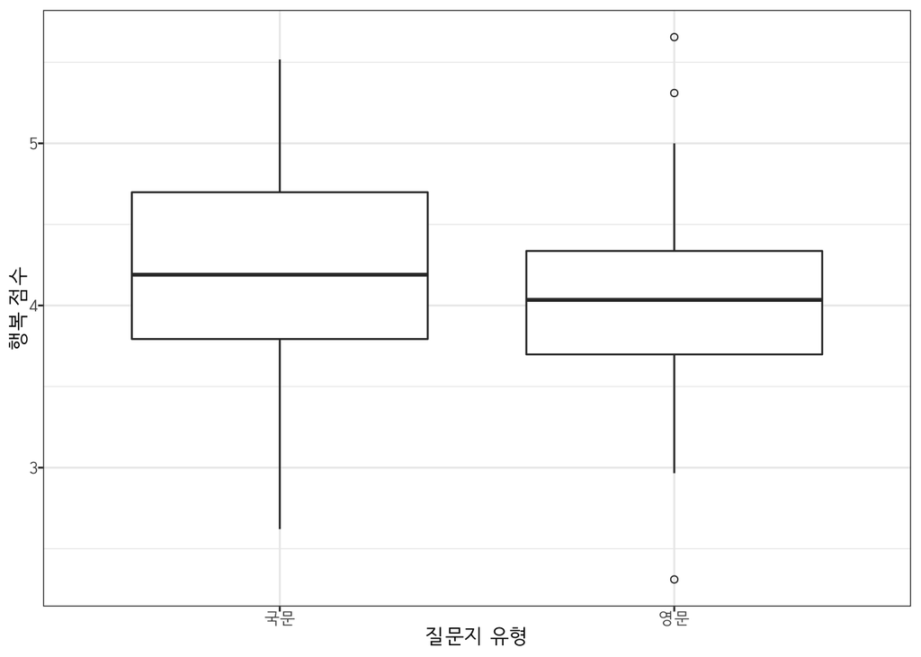

### `t.test()` on means

Welch Two Sample t-test: `Scores` by `Group`

| Test statistic | df | P value | Alternative hypothesis | mean in group 국문 | mean in group 영문 |
| --- | --- | --- | --- | --- | --- |
| 2.041 | 141 | 0.04315 * | two.sided | 4.209 | 4.007 |

## 소요시간 비교

초 단위로 측정한 소요시간에서는 예상한 바와 같이 상당한 차이가 관찰된다. 평균, 중위수에서도 차이가 뚜렷할 뿐 아니라 `boxplot()`과 t-test에서 매우 큰 차이를 보인다. 평균적으로 117.3초, 즉 1분 57초정도 국문 질문지에 더 빨리 응답한다. 중위소요시간을 비교해 봐도 140.5 초, 약 2분 20초 만큼 국문 질문지에 더 빨리 응답한다.

### `summary()`

- **국문**:

  | Min. | 1st Qu. | Median | Mean | 3rd Qu. | Max. | NA’s |
  | --- | --- | --- | --- | --- | --- | --- |
  | 104 | 200 | 305 | 332.9 | 392 | 841 | 13 |

- **영문**:

  | Min. | 1st Qu. | Median | Mean | 3rd Qu. | Max. | NA’s |
  | --- | --- | --- | --- | --- | --- | --- |
  | 113 | 332.2 | 445.5 | 450.2 | 548 | 1205 | 16 |

### `geom_boxplot()`

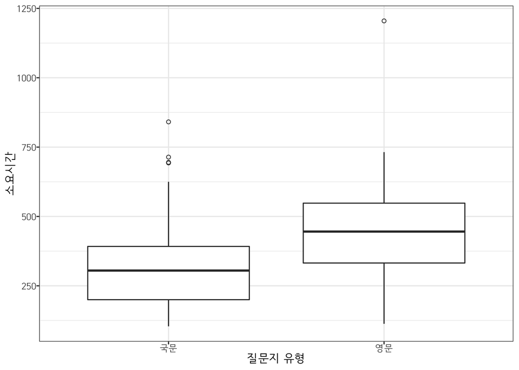

### `t.test()` on means

Welch Two Sample t-test: `Duration` by `Group`

| Test statistic | df | P value | Alternative hypothesis | mean in group 국문 | mean in group 영문 |
| --- | --- | --- | --- | --- | --- |
| -4.266 | 148.3 | 3.536e-05 * * * | two.sided | 332.9 | 450.2 |

## Difference

손으로 집계한 값과 컴퓨터로 집계한 값들을 산점도로 비교해 본다.

### `plot()`

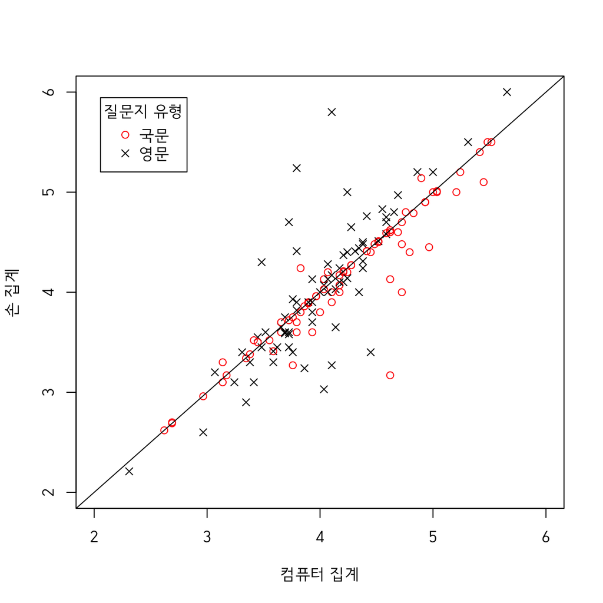

### `geom_point()`

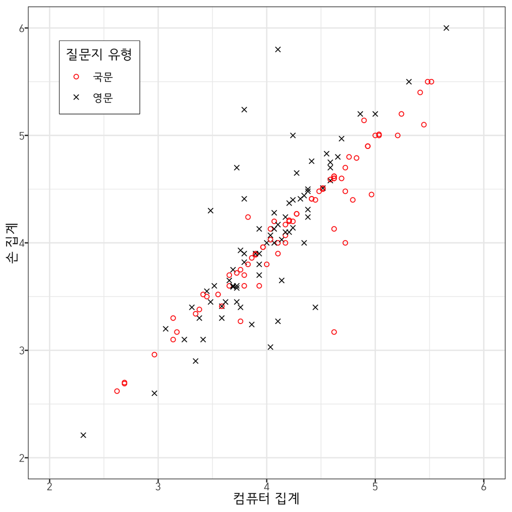

### `summary()`

- **국문**:

  | Min. | 1st Qu. | Median | Mean | 3rd Qu. | Max. | NA’s |
  | --- | --- | --- | --- | --- | --- | --- |
  | -1.451 | -0.06375 | -0.008 | -0.07704 | -0.001 | 0.412 | 14 |

- **영문**:

  | Min. | 1st Qu. | Median | Mean | 3rd Qu. | Max. | NA’s |
  | --- | --- | --- | --- | --- | --- | --- |
  | -1.048 | -0.1293 | 0.015 | 0.03546 | 0.162 | 1.697 | 16 |

### `geom_boxplot()`

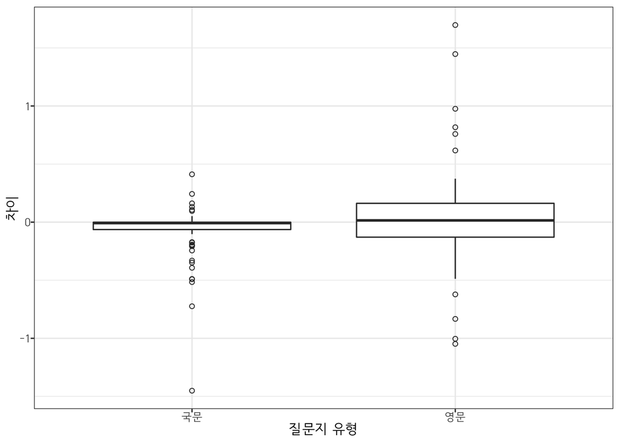

### 평균과 표준편차

국문 질문지를 사용한 경우 컴퓨터로 집계한 것과 손으로 집계한 것의 차이의 평균은 -0.077점, 표준편차는 0.229 점, 표본의 크기는 $75 + 1 = 76$이므로 $표준오차 = 표준편차/\sqrt{표본의 크기}$ 로부터 모집단의 평균은 대략 -0.077 $\pm$ 0.026 점 정도될 것으로 추측할 수 있다. 영문 질문지를 사용한 경우 표본의 평균은 0.035점, 표준편차는 0.423 점, 표본의 크기는 $73 + 1 = 74$이므로 모집단의 평균은 대략 0.035 $\pm$ 0.049 점 정도될 것으로 추측할 수 있다. 즉, 국문 질문지의 경우 컴퓨터로 집계하는 것보다 손으로 집계할 경우 0.08 점 정도 낮게 나올 수 있고, 영문 질문지를 사용할 경우 평균적으로 차이가 나지 않지만 편차는 국문 질문지보다 두 배 정도 크다는 것을 알 수 있다.

### 표본 평균

| 국문 | 영문 |
| --- | --- |
| -0.077 | 0.035 |

### 표본 표준편차

| 국문 | 영문 |
| --- | --- |
| 0.229 | 0.423 |

### `t.test()`

- **국문**:

  One Sample t-test: `X[[i]]`

  | Test statistic | df | P value | Alternative hypothesis | mean of x |
  | --- | --- | --- | --- | --- |
  | -2.927 | 75 | 0.004527 * * | two.sided | -0.07704 |

- **영문**:

  One Sample t-test: `X[[i]]`

  | Test statistic | df | P value | Alternative hypothesis | mean of x |
  | --- | --- | --- | --- | --- |
  | 0.7207 | 73 | 0.4734 | two.sided | 0.03546 |